# House Price

```
[1]  524 1299
[1] 0.7789588
[1] 0.829042
```

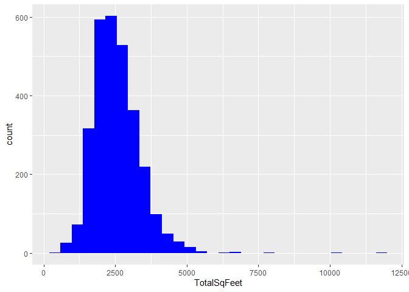

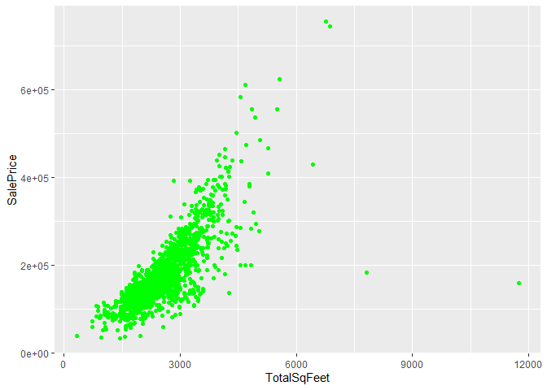

```r
#4、合并地面面积(GrLivArea)、与地下室面积(TotalBsmtSF)  => 为总居住面积(TotalSqFeet)
all$TotalSqFeet = all$GrLivArea + all$TotalBsmtSF
#因为都以平方英尺square feet为单位，所以TotalSqFeet为连续型变量


#可视化TotalSqFeet
qplot(TotalSqFeet, data=all, geom='histogram', fill=I('blue'), ylab='count')
qplot(TotalSqFeet,SalePrice,data=all,col=I('green'))



#从与SalePrice的图中，看见有两个点与(正相关)趋势相反  =>异常值点
which(all$TotalSqFeet>7500 & all$SalePrice<200000)


#新变量与SalePrice的相关性cor
cor(all$SalePrice, all$TotalSqFeet, use= "pairwise.complete.obs")
#当把这2个异常值剔除后，cor增加了约5%
cor(all$SalePrice[-c(524, 1299)], all$TotalSqFeet[-c(524, 1299)], use= "pairwise.complete.obs")
#所以删除这2个房子
all = all[-c(524, 1299),]
```

```
[1] 0.196875
```

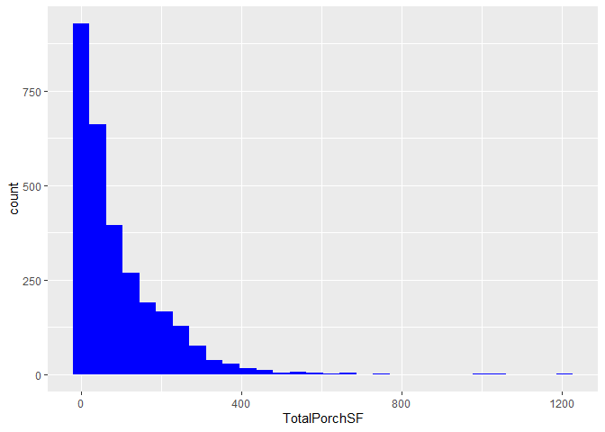

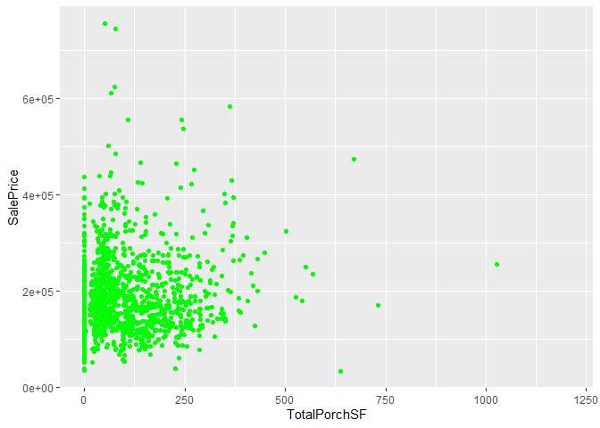

```r
#5、合并与porch有关的变量   =>为TotalPorchSF
all$TotalPorchSF = all$OpenPorchSF + all$EnclosedPorch + all$X3SsnPorch + all$ScreenPorch
#因为都以平方英尺为单位，所以TotalPorchSF是连续型变量


#可视化TotalPorchSF
qplot(TotalPorchSF, data=all, geom='histogram', fill=I('blue'), ylab='count')
qplot(TotalPorchSF, SalePrice, data=all, col=I('green'))


#新变量TotalPorchSF与目标变量之间的相关性
cor(all$SalePrice, all$TotalPorchSF, use= "pairwise.complete.obs")
#相关性不强
```

由TotalPorchSF与SalePrice的图发现：这两个没有什么相关性

用协方差检验，相关性只有约0.2 => 相关性不强

## 4.2 删除高度相关的特征

删除方法：1、找出两个高度相关的变量；2、删除与目标变量相关性更小的那个

```r
#再画协相关矩阵
all_numVar=all[,sapply(all, is.numeric)]
cor=cor(all_numVar, use="pairwise.complete.obs")


#求相关性非常高的两个变量
for (i in 1:nrow(cor)) {
  for (j in 1:i) {
    cor[i,j]=0
  }
}

cor[,'SalePrice']=0
cor['SalePrice',]=0


for (i in rownames(cor)) {
  for (j in colnames(cor)) {
    if(cor[i,j]>0.8 & cor[i,j]!=1) {
      print(i)
      print(j)
      cat('\n')
      }
  }
}


dropVars = c('YearRemodAdd', 'GarageYrBlt', 'GarageArea', 'GarageCond', 'TotalBsmtSF', 'TotalRmsAbvGrd', 'BsmtFinSF1')

all = all[,!(names(all) %in% dropVars)]
```

```
[1] "YearBuilt"
[1] "GarageYrBlt"

[1] "BsmtFinType2"
[1] "BsmtFinSF2"

[1] "TotalBsmtSF"
[1] "TotalSqFeet"

[1] "GrLivArea"
[1] "TotRmsAbvGrd"

[1] "GrLivArea"
[1] "TotalSqFeet"

[1] "Fireplaces"
[1] "FireplaceQu"

[1] "GarageCars"
[1] "GarageArea"

[1] "GarageQual"
[1] "GarageCond"

[1] "PoolArea"
[1] "PoolQC"
```

## 4.3 分离定量特征 (标准化、one-hot encoding)

将定量特征、和非定量分离 => 一个用于标准化(num_df)、一个用于哑编码(factor_df)

都不含目标变量SalePrice

```r
#1、准备要标准化的数据：

#原始的数值变量 - 后来转化成factor的变量 + 后来不是用标签编码增加的数值变量

#原始的数值特征
numVar_name_initial       #后来增加的数值特征来源：1、标签编码；2、在特征工程中，新增的定量数值特征

# - 后来转化成factor的特征
numVar_name_norm = numVar_name_initial[!(numVar_name_initial %in% c('MSSubClass', 'MoSold', 'YrSold', 'SalePrice', 'OverallQual', 'OverallCond'))]

#在特征工程中，新增的定量数值特征
numVar_name_norm = append(numVar_name_norm, c('Age', 'TotalPorchSF', 'TotBathrooms', 'TotalSqFeet'))


#用于标准化的(定量)数值特征
num_df = all[, names(all) %in% numVar_name_norm]


#不用于标准化的特征
factor_df = all[, !(names(all) %in% numVar_name_norm)]
factor_df = factor_df[, names(factor_df) != 'SalePrice']

#其实factor_df里面还包含数值型变量(但是哑编码时不会管这些数值型变量，所以无所谓)
```

```
 [1] "MSSubClass"    "LotFrontage"   "LotArea"       "OverallQual"
 [5] "OverallCond"   "YearBuilt"     "YearRemodAdd"  "MasVnrArea"
 [9] "BsmtFinSF1"    "BsmtFinSF2"    "BsmtUnfSF"     "TotalBsmtSF"
[13] "X1stFlrSF"     "X2ndFlrSF"     "LowQualFinSF"  "GrLivArea"
[17] "BsmtFullBath"  "BsmtHalfBath"  "FullBath"      "HalfBath"
[21] "BedroomAbvGr"  "KitchenAbvGr"  "TotRmsAbvGrd"  "Fireplaces"
[25] "GarageYrBlt"   "GarageCars"    "GarageArea"    "WoodDeckSF"
[29] "OpenPorchSF"   "EnclosedPorch" "X3SsnPorch"    "ScreenPorch"
[33] "PoolArea"      "MiscVal"       "MoSold"        "YrSold"
[37] "SalePrice"
```

### 4.3.1 标准化

num_df中的特征都标准化

```r
#1、将num_df中|偏度|>0.8的定量特征，降低偏度 (取对数)
for(i in 1:ncol(num_df)){
        if (abs(skew(num_df[,i]))>0.8){
                num_df[,i] = log(num_df[,i] +1)
        }
}




#2、标准化(归一化)
library(caret)
PreNum = preProcess(num_df, method=c("center", "scale"))       # method默认是c("center", "scale")
norm_df = predict(PreNum, num_df)
```

num_df 标准化后–> nrom_df

### 4.3.2 哑编码(one-hot encoding)

给factor_df中的factor变量创建虚拟变量

```r
#给factor_df中的factor型变量哑编码
dummy_df = as.data.frame(model.matrix(~.-1, factor_df))

dim(dummy_df)
```

```
[1] 2917  201
```

factor_df 哑编码后–> dummy_df

## 4.4 删除出现次数很少的level

哑编码后，在dummy_df中，分别去除train、test中含有极少1的虚拟变量

```r
#test集：

#1、没出现过的level
test_level_zero = which( colSums( dummy_df[(nrow(all[!is.na(all$SalePrice) , ]) +1):nrow(all) , ])==0 )
colnames(dummy_df[,test_level_zero])

#   删去这些level(即这些虚拟变量)
dummy_df = dummy_df[ ,-test_level_zero]





#train集：

#1、没出现过的level
train_level_zero = which( colSums(dummy_df[1:nrow(all[!is.na(all$SalePrice), ]), ])==0 )
colnames(dummy_df[,train_level_zero])

#   删去这些level(即虚拟变量)
dummy_df = dummy_df[ ,-train_level_zero]



#2、出现次数少于10次
fewOne = which( colSums(dummy_df[1:nrow(all[!is.na(all$SalePrice), ]), ])<10 )
colnames(dummy_df[,fewOne])

#   删去此level(即一个虚拟变量)
dummy_df = dummy_df[,-fewOne]



dim(dummy_df)


#以上删除的是无序特征中出现次数很少的level(因为删的是虚拟变量，只有无序特征才有虚拟变量)
```

```
 [1] "Condition2RRAe"     "Condition2RRAn"     "Condition2RRNn"
 [4] "HouseStyle2.5Fin"   "RoofMatlMembran"    "RoofMatlMetal"
 [7] "RoofMatlRoll"       "Exterior1stImStucc" "Exterior1stStone"
[10] "Exterior2ndOther"   "HeatingOthW"        "ElectricalMix"
[13] "MiscFeatureTenC"
NULL
 [1] "MSSubClass1 story unf attic" "LotConfigFR3"
 [3] "NeighborhoodBlueste"         "NeighborhoodNPkVill"
 [5] "Condition1PosA"              "Condition1RRNe"
 [7] "Condition1RRNn"              "Condition2Feedr"
 [9] "Condition2PosA"              "Condition2PosN"
[11] "RoofStyleMansard"            "RoofStyleShed"
[13] "RoofMatlWdShake"             "RoofMatlWdShngl"
[15] "Exterior1stAsphShn"          "Exterior1stBrkComm"
[17] "Exterior1stCBlock"           "Exterior2ndAsphShn"
[19] "Exterior2ndBrk Cmn"          "Exterior2ndCBlock"
[21] "Exterior2ndStone"            "FoundationStone"
[23] "FoundationWood"              "HeatingGrav"
[25] "HeatingWall"                 "ElectricalFuseP"
[27] "GarageTypeCarPort"           "MiscFeatureOthr"
[29] "SaleTypeCon"                 "SaleTypeConLD"
[31] "SaleTypeConLI"               "SaleTypeConLw"
[33] "SaleTypeCWD"                 "SaleTypeOth"
[35] "SaleConditionAdjLand"
[1] 2917  152
```

## 4.5 合并norm_df和dummy_df

将标准化后的norm_df、和哑编码+除去少数level后的dummy_df合并

都不含目标变量SalePrice

```r
all2_x = cbind(norm_df, dummy_df)   #不含SalePrice
```

**本节以上内容都是对影响因子处理 => 影响因子处理完毕**

## 4.6 目标变量

### 4.6.1 降低目标变量的偏度(取对数)

```
[1] 1.877427
[1] 0.1213182
```

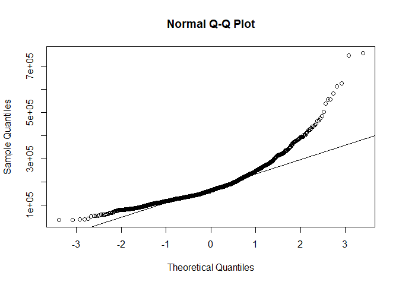

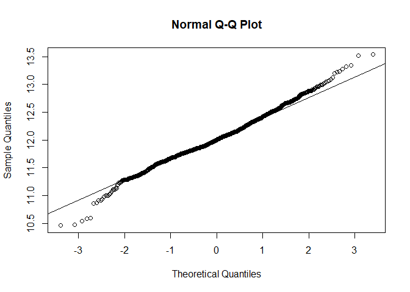

```r
#求目标变量的偏度
skew(all$SalePrice)

#画Q-Q图
qqnorm(all$SalePrice)
qqline(all$SalePrice)

#降低偏度(取对数)
all$SalePrice = log(all$SalePrice)   #这里是否+1都可以
skew(all$SalePrice)

#降低偏度后的Q-Q图
qqnorm(all$SalePrice)
qqline(all$SalePrice)
```

偏度 1.877427>0 : 右偏度过高 并且Q-Q图也显示售价不呈正态分布 降低偏度后，偏度约为0.12

## 4.7 从all2_x中分离train_x、test_x (都不含目标变量SalePrice)

```r
train_x=all2_x[!is.na(all$SalePrice),]
test_x=all2_x[is.na(all$SalePrice),]
```

# 5 构建xgboost模型

[output not shown]

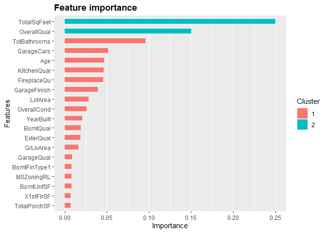

```r
library(xgboost)

#1、数据准备(dtrain、dtest)
train_y = all$SalePrice[!is.na(all$SalePrice)]

dtrain = xgb.DMatrix(data = as.matrix(train_x), label= train_y)
dtest = xgb.DMatrix(data = as.matrix(test_x))





#2、超参数准备

#(1)超参数网格
xgb_grid = expand.grid(

  nrounds = 1000,                 #迭代次数   (通常设置较大的迭代次数，和较小学习率)

  eta = c(0.1, 0.05, 0.01),       #学习速率


  min_child_weight=c(1, 2, 3, 4 ,5),  #决定节点分裂是否结束  (需要cv来调整)
  #用于避免'过拟合'：1、值较大时，可以避免模型学习到局部的特殊样本；2、值越大，越容易欠拟合；3、值越小，越容易过拟合

  max_depth = c(2, 3, 4, 5, 6),       #决定树的最大深度      (需要cv来调整)
  #用于避免'过拟合'：值越大，模型会学习到更具体、更局部的样本


  gamma = 0,                      #阈值：节点分裂所需要的最小的 损失函数下降值   (值越大，算法越保守)


  subsample=1,                    #每棵树，随机采样的样本占比：值越小，算法越保守，避免过拟合，但是过小，会导致欠拟合

  colsample_bytree=1              #每棵树，随机采样的列数(特征)的占比
)




#(2)、用5折交叉验证选择最佳超参数组合
library(caret)

#my_control = trainControl(method="cv", number=5)       #method='cv': 交叉验证、number：几折   =>5折交叉验证

#xgb_caret = train(x=train_x, y=train_y, method='xgbTree', trControl= my_control, tuneGrid=xgb_grid)

#head(xgb_caret)

#xgb_caret$bestTune   #获取最佳超参数组合





#(3)、最佳参数组合
xgb_param=list(
        booster="gbtree",       #每次迭代的模型：树模型(默认)
        objective="reg:linear", #学习目标：(需要被最小化的)损失函数(目标函数)

        eta=0.05,       #默认值=0.3
        gamma=0,        #默认值=0

        min_child_weight=4,    #默认值=1
        max_depth=3,           #默认值=6

        subsample=1,           #默认值=1
        colsample_bytree=1     #默认值=1
)





#3、确定最佳nrounds(迭代次数)      (对最佳超参数组合，用5折交叉验证的方法)
xgb_cv = xgb.cv( params = xgb_param, data = dtrain, nrounds = 500, nfold = 5, showsd = T, stratified = T, print_every_n = 40, early_stopping_rounds = 10, maximize = F)






#4、建立xgboost模型   (用最佳超参数组合、最佳nrounds)
xgb = xgb.train(data = dtrain, params=xgb_param, nrounds = 454)





#5、用得到的xgb模型预测dtest的SalePrice
xgb_pred = predict(xgb, dtest)

xgb_prediction = exp(xgb_pred)     #将预测结果(对数)，逆运算，得到=>售价

head(xgb_prediction)





#6、特征重要性
library(Ckmeans.1d.dp)

#得到此xgb模型的特征重要性
varImp_xgb= xgb.importance (colnames(train_x), xgb)

#可视化前20个特征重要性
xgb.ggplot.importance(varImp_xgb[1:20])
#xgb.ggplot.importance(importance_matrix = varImp_xgb[1:20], rel_to_first = TRUE)
```